# Subject: Machine Learning

### Subject code: 3170724

#### **Name:**Himanshu Gupta,**Enrollment:**20000107133

#### **Name:**Chirag Singh,**Enrollment:**20000107121

#### Division:A

#### https://www.kaggle.com/datasets/rounakbanik/pokemon

## CO-1 ASSIGNMENT:

**1.**Implement the techniques to deal with outliers.

```python
from google.colab import files
uploaded = files.upload()
```

```
Saving pokemon.csv to pokemon.csv
```

|  | abilities | against_bug | against_dark | against_dragon | against_electric | against_fairy | against_fight | against_fire | against_flying | against_ghost | ... | percentage_male | pokedex_number | sp_attack | sp_defense | speed | type1 | type2 | weight_kg | generation | is_legendary |
| --- | --- | --- | --- | --- | --- | --- | --- | --- | --- | --- | --- | --- | --- | --- | --- | --- | --- | --- | --- | --- | --- |
| 0 | ['Overgrow', 'Chlorophyll'] | 1.00 | 1.0 | 1.0 | 0.5 | 0.5 | 0.5 | 2.0 | 2.0 | 1.0 | ... | 88.1 | 1 | 65 | 65 | 45 | grass | poison | 6.9 | 1 | 0 |
| 1 | ['Overgrow', 'Chlorophyll'] | 1.00 | 1.0 | 1.0 | 0.5 | 0.5 | 0.5 | 2.0 | 2.0 | 1.0 | ... | 88.1 | 2 | 80 | 80 | 60 | grass | poison | 13.0 | 1 | 0 |
| 2 | ['Overgrow', 'Chlorophyll'] | 1.00 | 1.0 | 1.0 | 0.5 | 0.5 | 0.5 | 2.0 | 2.0 | 1.0 | ... | 88.1 | 3 | 122 | 120 | 80 | grass | poison | 100.0 | 1 | 0 |
| 3 | ['Blaze', 'Solar Power'] | 0.50 | 1.0 | 1.0 | 1.0 | 0.5 | 1.0 | 0.5 | 1.0 | 1.0 | ... | 88.1 | 4 | 60 | 50 | 65 | fire | NaN | 8.5 | 1 | 0 |
| 4 | ['Blaze', 'Solar Power'] | 0.50 | 1.0 | 1.0 | 1.0 | 0.5 | 1.0 | 0.5 | 1.0 | 1.0 | ... | 88.1 | 5 | 80 | 65 | 80 | fire | NaN | 19.0 | 1 | 0 |
| ... | ... | ... | ... | ... | ... | ... | ... | ... | ... | ... | ... | ... | ... | ... | ... | ... | ... | ... | ... | ... | ... |
| 796 | ['Beast Boost'] | 0.25 | 1.0 | 0.5 | 2.0 | 0.5 | 1.0 | 2.0 | 0.5 | 1.0 | ... | NaN | 797 | 107 | 101 | 61 | steel | flying | 999.9 | 7 | 1 |
| 797 | ['Beast Boost'] | 1.00 | 1.0 | 0.5 | 0.5 | 0.5 | 2.0 | 4.0 | 1.0 | 1.0 | ... | NaN | 798 | 59 | 31 | 109 | grass | steel | 0.1 | 7 | 1 |
| 798 | ['Beast Boost'] | 2.00 | 0.5 | 2.0 | 0.5 | 4.0 | 2.0 | 0.5 | 1.0 | 0.5 | ... | NaN | 799 | 97 | 53 | 43 | dark | dragon | 888.0 | 7 | 1 |
| 799 | ['Prism Armor'] | 2.00 | 2.0 | 1.0 | 1.0 | 1.0 | 0.5 | 1.0 | 1.0 | 2.0 | ... | NaN | 800 | 127 | 89 | 79 | psychic | NaN | 230.0 | 7 | 1 |
| 800 | ['Soul-Heart'] | 0.25 | 0.5 | 0.0 | 1.0 | 0.5 | 1.0 | 2.0 | 0.5 | 1.0 | ... | NaN | 801 | 130 | 115 | 65 | steel | fairy | 80.5 | 7 | 1 |

801 rows × 41 columns

Distributions

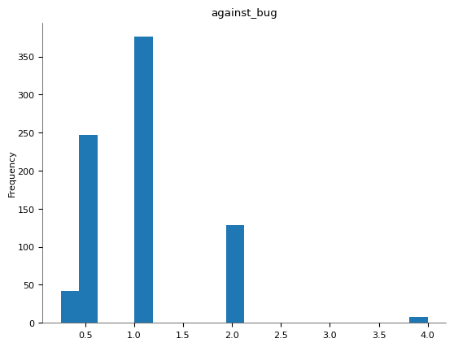

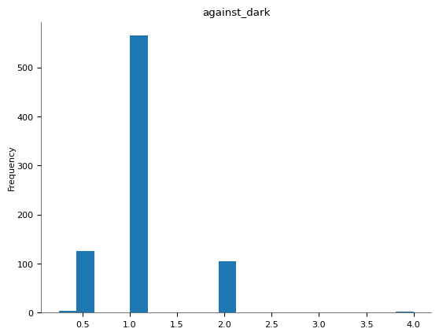

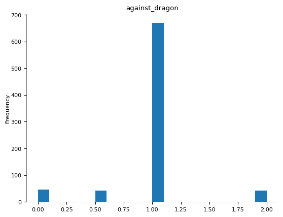

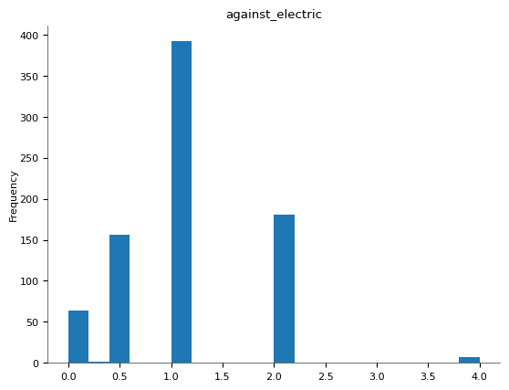

2-d distributions

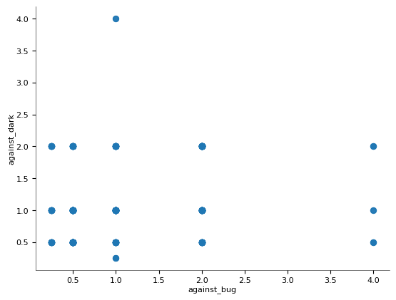

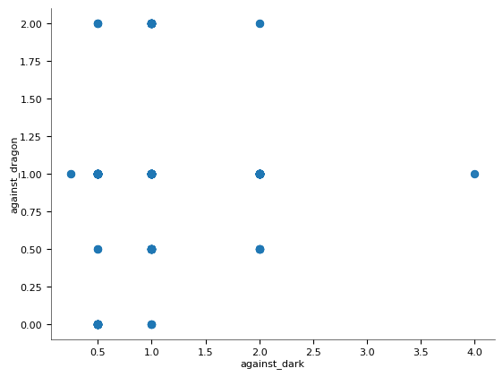

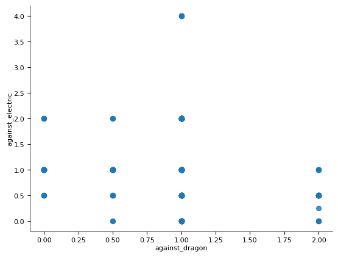

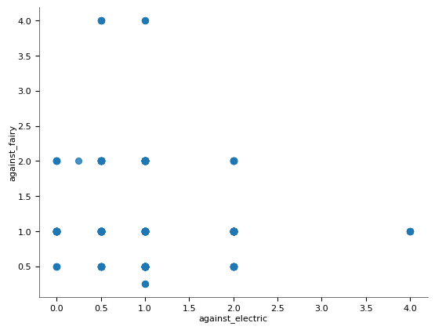

Time series

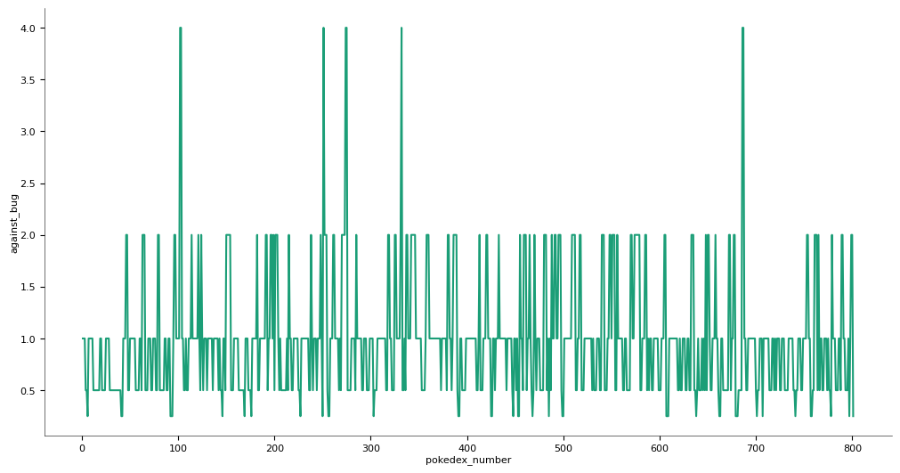

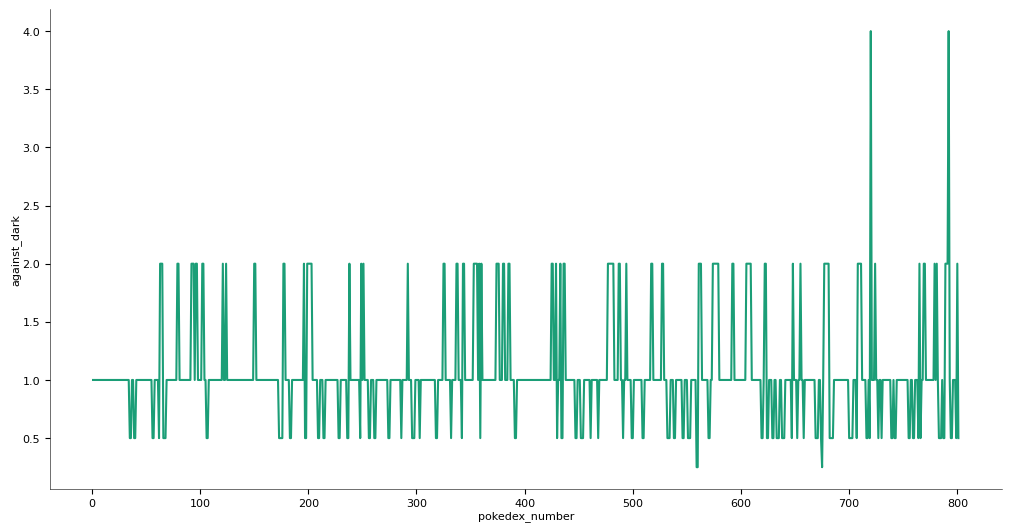

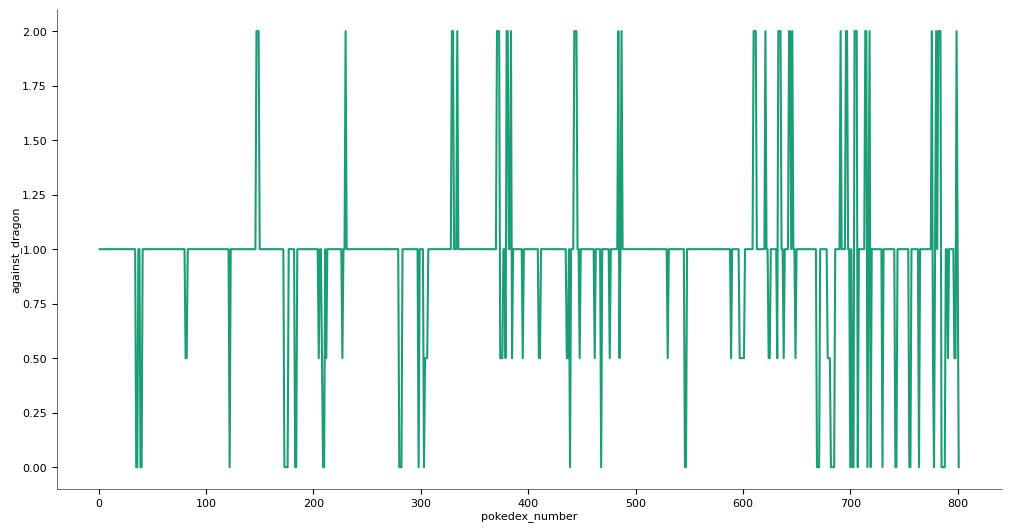

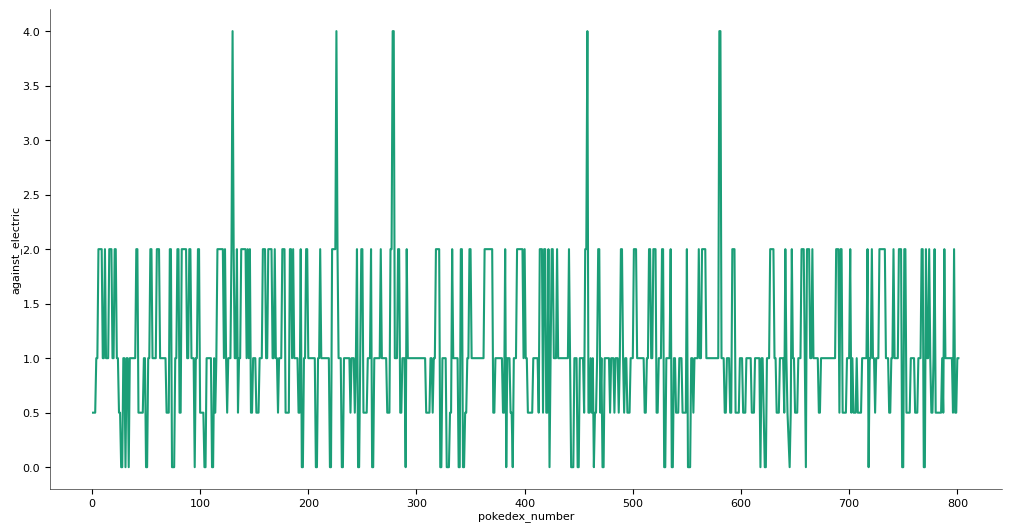

Values

[4 more figures not shown]

```python
import pandas as pd
# Load the pokemon dataset from scikit-learn
data =pd.read_csv("pokemon.csv")

data
```

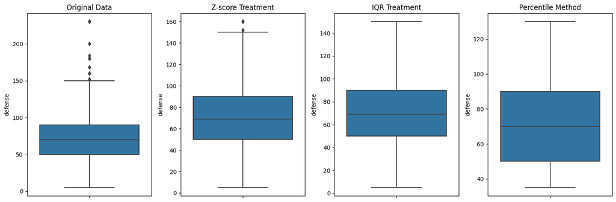

```python
import pandas as pd
import matplotlib.pyplot as plt
import seaborn as sns
from scipy.stats import zscore

# Read data from CSV file
data = pd.read_csv('pokemon.csv')

# Function to detect and remove outliers using Z-score
def remove_outliers_zscore(data, column):
    z_scores = zscore(data[column])
    abs_z_scores = abs(z_scores)
    filtered_data = data[(abs_z_scores < 3)]
    return filtered_data

# Function to detect and remove outliers using IQR
def remove_outliers_iqr(data, column):
    Q1 = data[column].quantile(0.25)
    Q3 = data[column].quantile(0.75)
    IQR = Q3 - Q1
    filtered_data = data[~((data[column] < (Q1 - 1.5 * IQR)) | (data[column] > (Q3 + 1.5 * IQR)))]
    return filtered_data

# Function to detect and remove outliers using percentile method
def remove_outliers_percentile(data, column):
    lower_bound = data[column].quantile(0.05)
    upper_bound = data[column].quantile(0.95)
    filtered_data = data[(data[column] >= lower_bound) & (data[column] <= upper_bound)]
    return filtered_data

# Detect and remove outliers using Z-score
data_without_outliers_zscore = remove_outliers_zscore(data, 'defense')

# Detect and remove outliers using IQR
data_without_outliers_iqr = remove_outliers_iqr(data, 'defense')

# Detect and remove outliers using percentile method
data_without_outliers_percentile = remove_outliers_percentile(data, 'defense')

# Plotting graphs to visualize data before and after outlier removal
plt.figure(figsize=(15, 5))
plt.subplot(1, 4, 1)
sns.boxplot(y=data['defense'])
plt.title('Original Data')

plt.subplot(1, 4, 2)
sns.boxplot(y=data_without_outliers_zscore['defense'])
plt.title('Z-score Treatment')

plt.subplot(1, 4, 3)
sns.boxplot(y=data_without_outliers_iqr['defense'])
plt.title('IQR Treatment')

plt.subplot(1, 4, 4)
sns.boxplot(y=data_without_outliers_percentile['defense'])
plt.title('Percentile Method')

plt.tight_layout()
plt.show()
```

2. Implement the techniques to deal with missing values.

```python
NA = pd.DataFrame(data=[data.isna().sum().tolist(), ["{:.2f}".format(i)+'%' \
           for i in (data.isna().sum()/data.shape[0]*100).tolist()]],
           columns=data.columns, index=['NA Count', 'NA Percent']).transpose()

          # we  had made a new data frame which shows the number of missing values in each column
NA.style.background_gradient(cmap="Pastel1_r", subset=['NA Count'])
```

|  | NA Count | NA Percent |
| --- | --- | --- |
| abilities | 0 | 0.00% |
| against_bug | 0 | 0.00% |
| against_dark | 0 | 0.00% |
| against_dragon | 0 | 0.00% |
| against_electric | 0 | 0.00% |
| against_fairy | 0 | 0.00% |
| against_fight | 0 | 0.00% |
| against_fire | 0 | 0.00% |
| against_flying | 0 | 0.00% |
| against_ghost | 0 | 0.00% |
| against_grass | 0 | 0.00% |
| against_ground | 0 | 0.00% |
| against_ice | 0 | 0.00% |
| against_normal | 0 | 0.00% |
| against_poison | 0 | 0.00% |
| against_psychic | 0 | 0.00% |
| against_rock | 0 | 0.00% |
| against_steel | 0 | 0.00% |
| against_water | 0 | 0.00% |
| attack | 0 | 0.00% |
| base_egg_steps | 0 | 0.00% |
| base_happiness | 0 | 0.00% |
| base_total | 0 | 0.00% |
| capture_rate | 0 | 0.00% |
| classfication | 0 | 0.00% |
| defense | 0 | 0.00% |
| experience_growth | 0 | 0.00% |
| height_m | 20 | 2.50% |
| hp | 0 | 0.00% |
| japanese_name | 0 | 0.00% |
| name | 0 | 0.00% |
| percentage_male | 98 | 12.23% |
| pokedex_number | 0 | 0.00% |
| sp_attack | 0 | 0.00% |
| sp_defense | 0 | 0.00% |
| speed | 0 | 0.00% |
| type1 | 0 | 0.00% |
| type2 | 384 | 47.94% |
| weight_kg | 20 | 2.50% |
| generation | 0 | 0.00% |
| is_legendary | 0 | 0.00% |

```python
import pandas as pd
# Read data from CSV file
data = pd.read_csv('pokemon.csv')
# Fill missing values in the 'age' column with the mean
data['percentage_male'] = data['percentage_male'].fillna(data['percentage_male'].mean())
data['height_m'] = data['height_m'].fillna(data['height_m'].mean())
data['weight_kg'] = data['weight_kg'].fillna(data['weight_kg'].mean())
data=data.drop(columns="type2")
NA = pd.DataFrame(data=[data.isna().sum().tolist(), ["{:.2f}".format(i)+'%' \
           for i in (data.isna().sum()/data.shape[0]*100).tolist()]],
           columns=data.columns, index=['NA Count', 'NA Percent']).transpose()
# we  had made a new data frame which shows the number of missing values in each column
NA.style.background_gradient(cmap="Pastel1_r", subset=['NA Count'])
```

|  | NA Count | NA Percent |
| --- | --- | --- |
| abilities | 0 | 0.00% |
| against_bug | 0 | 0.00% |
| against_dark | 0 | 0.00% |
| against_dragon | 0 | 0.00% |
| against_electric | 0 | 0.00% |
| against_fairy | 0 | 0.00% |
| against_fight | 0 | 0.00% |
| against_fire | 0 | 0.00% |
| against_flying | 0 | 0.00% |
| against_ghost | 0 | 0.00% |
| against_grass | 0 | 0.00% |
| against_ground | 0 | 0.00% |
| against_ice | 0 | 0.00% |
| against_normal | 0 | 0.00% |
| against_poison | 0 | 0.00% |
| against_psychic | 0 | 0.00% |
| against_rock | 0 | 0.00% |
| against_steel | 0 | 0.00% |
| against_water | 0 | 0.00% |
| attack | 0 | 0.00% |
| base_egg_steps | 0 | 0.00% |
| base_happiness | 0 | 0.00% |
| base_total | 0 | 0.00% |
| capture_rate | 0 | 0.00% |
| classfication | 0 | 0.00% |
| defense | 0 | 0.00% |
| experience_growth | 0 | 0.00% |
| height_m | 0 | 0.00% |
| hp | 0 | 0.00% |
| japanese_name | 0 | 0.00% |
| name | 0 | 0.00% |
| percentage_male | 0 | 0.00% |
| pokedex_number | 0 | 0.00% |
| sp_attack | 0 | 0.00% |
| sp_defense | 0 | 0.00% |
| speed | 0 | 0.00% |
| type1 | 0 | 0.00% |
| weight_kg | 0 | 0.00% |
| generation | 0 | 0.00% |
| is_legendary | 0 | 0.00% |

## CO-2 ASSIGNMENT:

3.Implement distance measuring techniques for two features of your dataset: (a) Euclidean (b)Minkowski (c) Manhattan (d) Jaccard (e) Cosine (f) Simple matching coefficient (g)hamming (distance libraries-numpy, scipy, math)

```python
import pandas as pd
import numpy as np
from scipy.spatial import distance
import math

# Read data from CSV file
data = pd.read_csv('pokemon.csv')
# Select two features (in this case, 'math.grade' and 'science.grade' column for demonstration)
feature1 = data['attack']
feature2 = data['defense']

# Euclidean Distance
euclidean_distance = np.linalg.norm(feature1 - feature2)

# Minkowski Distance (p=3 for demonstration)
minkowski_distance = distance.minkowski(feature1, feature2, p=3)

# Manhattan Distance
manhattan_distance = np.sum(np.abs(feature1 - feature2))


# Cosine Similarity (use 1 - cosine similarity for cosine distance)
cosine_distance = distance.cosine(feature1, feature2)

# Print calculated distances
print(f'Euclidean Distance: {euclidean_distance}')
print(f'Minkowski Distance (p=3): {minkowski_distance}')
print(f'Manhattan Distance: {manhattan_distance}')

print(f'Cosine Distance: {cosine_distance}')
```

```
Euclidean Distance: 928.0043103348173
Minkowski Distance (p=3): 388.20726163933887
Manhattan Distance: 19236
Cosine Distance: 0.07868195495283103
```

```python
import pandas as pd

# Read data from CSV file
data = pd.read_csv('pokemon.csv')
# Apply one-hot encoding to the 'gender' column
data = pd.get_dummies(data, columns=['generation'])


column1 = data['is_legendary']
column2 = data['generation_1']

# Simple Matching Coefficient
matching_coefficient = sum(c1 == c2 for c1, c2 in zip(column1, column2)) / len(column1)

# Hamming Distance
hamming_distance = sum(c1 != c2 for c1, c2 in zip(column1, column2))

# Jaccard Distance
jaccard_distance = 1 - sum(c1 == c2 == 1 for c1, c2 in zip(column1, column2)) / sum(c1 == 1 or c2 == 1 for c1, c2 in zip(column1, column2))

# Print calculated distances
print(f'Simple Matching Coefficient: {matching_coefficient}')
print(f'Hamming Distance: {hamming_distance}')
print(f'Jaccard Distance: {jaccard_distance}')
```

```
Simple Matching Coefficient: 0.7365792759051186
Hamming Distance: 211
Jaccard Distance: 0.9768518518518519
```

4. Implement any data reduction technique.

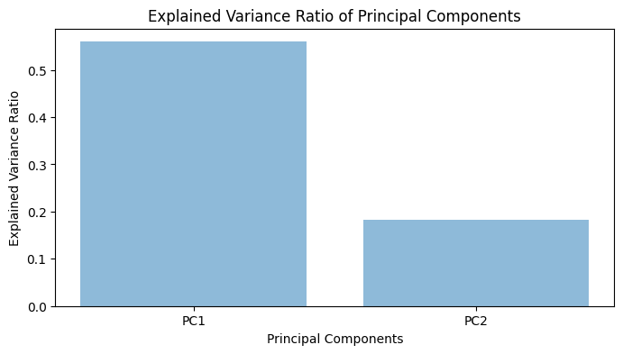

```
        PC1       PC2
0 -1.521357  0.018552
1 -0.239144 -0.054111
2  3.246270  0.671341
3 -1.668637 -0.664746
4 -0.282513 -0.762577
```

```python
import pandas as pd
import numpy as np
from sklearn.decomposition import PCA
import matplotlib.pyplot as plt

# Load Pokémon dataset from CSV file
pokemon_data = pd.read_csv('pokemon.csv')

# Select numerical features for PCA
features = ['base_total', 'attack', 'defense', 'sp_attack','sp_defense', 'speed']

# Separate features from the target variable (if applicable)
X = pokemon_data[features]

# Standardize the data (important for PCA)
mean = np.mean(X, axis=0)
std_dev = np.std(X, axis=0)
X_standardized = (X - mean) / std_dev

# Apply PCA to reduce dimensionality
n_components = 2  # Number of components to keep
pca = PCA(n_components=n_components)
X_pca = pca.fit_transform(X_standardized)

# Create a DataFrame with the reduced data
pca_df = pd.DataFrame(data=X_pca, columns=[f'PC{i+1}' for i in range(n_components)])

# Concatenate the reduced data with the target variable (if applicable)
# final_df = pd.concat([pca_df, pd.Series(y, name='target')], axis=1)

# Explained variance ratio
explained_variance_ratio = pca.explained_variance_ratio_

# Plot the explained variance ratio
plt.figure(figsize=(8, 4))
plt.bar(range(n_components), explained_variance_ratio, alpha=0.5, align='center')
plt.xlabel('Principal Components')
plt.ylabel('Explained Variance Ratio')
plt.xticks(range(n_components), [f'PC{i+1}' for i in range(n_components)])
plt.title('Explained Variance Ratio of Principal Components')
plt.show()

# Display the first few rows of the reduced data
print(pca_df.head())
```

## CO-3 ASSIGNMENT:

5. Implement various knn classification algorithms and do prediction for unknown data.

```python
import numpy as np
import pandas as pd
from sklearn.model_selection import train_test_split
from sklearn.neighbors import KNeighborsClassifier
from sklearn.metrics import accuracy_score

# Load Pokémon dataset from CSV file
pokemon_data = pd.read_csv('pokemon.csv')

# Select features and target variable
features = ['attack', 'defense', 'sp_attack', 'sp_defense', 'speed']
target = 'is_legendary'

# Prepare input features (X) and target variable (y)
X = pokemon_data[features]
y = pokemon_data[target]

# Split the dataset into training and testing sets
X_train, X_test, y_train, y_test = train_test_split(X, y, test_size=0.2, random_state=42)

# Define k-NN classifiers with different distance metrics
knn_euclidean = KNeighborsClassifier(n_neighbors=3, metric='euclidean')
knn_manhattan = KNeighborsClassifier(n_neighbors=3, metric='manhattan')
knn_chebyshev = KNeighborsClassifier(n_neighbors=3, metric='chebyshev')

# Train the k-NN classifiers on the training data
knn_euclidean.fit(X_train, y_train)
knn_manhattan.fit(X_train, y_train)
knn_chebyshev.fit(X_train, y_train)

# Predict the classes for the test data
y_pred_euclidean = knn_euclidean.predict(X_test)
y_pred_manhattan = knn_manhattan.predict(X_test)
y_pred_chebyshev = knn_chebyshev.predict(X_test)

# Calculate accuracy for each k-NN classifier
accuracy_euclidean = accuracy_score(y_test, y_pred_euclidean)
accuracy_manhattan = accuracy_score(y_test, y_pred_manhattan)
accuracy_chebyshev = accuracy_score(y_test, y_pred_chebyshev)

# Print the accuracy results
print("Accuracy (Euclidean Distance): {:.2f}".format(accuracy_euclidean))
print("Accuracy (Manhattan Distance): {:.2f}".format(accuracy_manhattan))
print("Accuracy (Chebyshev Distance): {:.2f}".format(accuracy_chebyshev))

# Predictions for unknown data
unknown_data = pd.DataFrame({

    'attack': [65,153],
    'defense': [65,154],
    'sp_attack': [65,165],
    'sp_defense': [65,155],
    'speed': [45,70]
})

prediction_euclidean = knn_euclidean.predict(unknown_data)
prediction_manhattan = knn_manhattan.predict(unknown_data)
prediction_chebyshev = knn_chebyshev.predict(unknown_data)

print("\nPrediction (Euclidean Distance) for Unknown Data: ", prediction_euclidean)
print("Prediction (Manhattan Distance) for Unknown Data: ", prediction_manhattan)
print("Prediction (Chebyshev Distance) for Unknown Data: ", prediction_chebyshev)
```

```
Accuracy (Euclidean Distance): 0.94
Accuracy (Manhattan Distance): 0.93
Accuracy (Chebyshev Distance): 0.94

Prediction (Euclidean Distance) for Unknown Data:  [0 1]
Prediction (Manhattan Distance) for Unknown Data:  [0 1]
Prediction (Chebyshev Distance) for Unknown Data:  [0 0]
```

6. Implement a decision tree classification algorithm.

```python
import numpy as np
import pandas as pd
from sklearn.model_selection import train_test_split
from sklearn.tree import DecisionTreeClassifier
from sklearn.metrics import accuracy_score, classification_report

# Load Pokémon dataset from CSV file
pokemon_data = pd.read_csv('pokemon.csv')

# Select features and target variable
features = [ 'attack', 'defense', 'sp_attack', 'sp_defense', 'speed']
target = 'is_legendary'

# Prepare input features (X) and target variable (y)
X = pokemon_data[features]
y = pokemon_data[target]

# Split the dataset into training and testing sets
X_train, X_test, y_train, y_test = train_test_split(X, y, test_size=0.2, random_state=42)

# Create a Decision Tree Classifier
clf = DecisionTreeClassifier(random_state=42)

# Train the classifier on the training data
clf.fit(X_train, y_train)

# Predict the classes for the test data
y_pred = clf.predict(X_test)

# Calculate accuracy
accuracy = accuracy_score(y_test, y_pred)
print("Accuracy:", accuracy)

# Generate a classification report
class_report = classification_report(y_test, y_pred, target_names=['Not Legendary', 'Legendary'])
print("Classification Report:\n", class_report)
```

```
Accuracy: 0.8944099378881988
Classification Report:
                precision    recall  f1-score   support

Not Legendary       0.93      0.96      0.94       143
    Legendary       0.54      0.39      0.45        18

     accuracy                           0.89       161
    macro avg       0.73      0.67      0.70       161
 weighted avg       0.88      0.89      0.89       161
```

7. Implement a support vector machine algorithm.

```python
import numpy as np
import pandas as pd
import matplotlib.pyplot as plt
from sklearn.model_selection import train_test_split
from sklearn.svm import SVC
from sklearn.metrics import accuracy_score, precision_score, recall_score, f1_score

# Load Pokémon dataset from CSV file
pokemon_data = pd.read_csv('pokemon.csv')

# Select features and target variable
features = ['sp_attack', 'sp_defense', 'attack', 'defense', 'speed']
target = 'is_legendary'

# Prepare input features (X) and target variable (y)
X = pokemon_data[features]
y = pokemon_data[target]

# Split the dataset into training and testing sets
X_train, X_test, y_train, y_test = train_test_split(X, y, test_size=0.2, random_state=42)

# Create a Support Vector Machine (SVM) classifier
svm_classifier = SVC(kernel='linear', C=1, random_state=42)

# Train the classifier on the training data
svm_classifier.fit(X_train, y_train)

# Predict the classes for the test data
y_pred = svm_classifier.predict(X_test)

# Calculate accuracy, precision, recall, and F1-score
accuracy = accuracy_score(y_test, y_pred)
precision = precision_score(y_test, y_pred)
recall = recall_score(y_test, y_pred)
fscore = f1_score(y_test, y_pred)

print("Accuracy:", accuracy)
print("Precision:", precision)
print("Recall:", recall)
print("F1 Score:", fscore)
```

```
Accuracy: 0.8944099378881988
Precision: 0.6666666666666666
Recall: 0.1111111111111111
F1 Score: 0.1904761904761905
```

8. Implement regression algorithms: (a)linear regression(b)logistic regression

(a). Linear Regression

```
Linear Regression R^2 Score: 0.5869133537564625
```

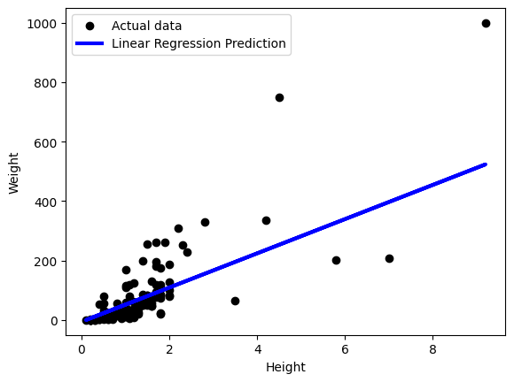

```python
import pandas as pd
from sklearn.model_selection import train_test_split
from sklearn.linear_model import LinearRegression
from sklearn.metrics import mean_squared_error, r2_score
import matplotlib.pyplot as plt

# Load Pokémon dataset from CSV file
pokemon_data = pd.read_csv('pokemon.csv')
# dealing with missing values
pokemon_data['height_m'] = pokemon_data['height_m'].fillna(pokemon_data['height_m'].mean())
pokemon_data['weight_kg'] = pokemon_data['weight_kg'].fillna(pokemon_data['weight_kg'].mean())
# Select features and target variable for linear regression
feature = ['height_m']
target = ['weight_kg']

# Prepare input features (X) and target variable (y) for linear regression
X = pokemon_data[feature]
y = pokemon_data[target]

# Split the dataset into training and testing sets
X_train, X_test, y_train, y_test = train_test_split(X, y, test_size=0.2, random_state=42)

# Create and train the Linear Regression model
linear_reg = LinearRegression()
linear_reg.fit(X_train, y_train)

# Make predictions using the test data
y_pred = linear_reg.predict(X_test)

# Calculate metrics for linear regression

r2 = r2_score(y_test, y_pred)


print("Linear Regression R^2 Score:", r2)

# Visualize the linear regression line
plt.scatter(X_test, y_test, color='black', label='Actual data')
plt.plot(X_test, y_pred, color='blue', linewidth=3, label='Linear Regression Prediction')
plt.xlabel('Height')
plt.ylabel('Weight')
plt.legend()
plt.show()
```

(b).Logistic Regression

```python
import pandas as pd
from sklearn.model_selection import train_test_split
from sklearn.linear_model import LogisticRegression
from sklearn.metrics import accuracy_score

# Load Pokémon dataset from CSV file
pokemon_data = pd.read_csv('pokemon.csv')

# Select features and target variable for logistic regression
features = ['sp_attack', 'sp_defense']
target = 'is_legendary'

# Prepare input features (X) and target variable (y) for logistic regression
X = pokemon_data[features]
y = pokemon_data[target]

# Split the dataset into training and testing sets
X_train, X_test, y_train, y_test = train_test_split(X, y, test_size=0.2, random_state=42)

# Create and train the Logistic Regression model
logistic_reg = LogisticRegression(random_state=42)
logistic_reg.fit(X_train, y_train)

# Make predictions using the test data
y_pred = logistic_reg.predict(X_test)

# Calculate accuracy for logistic regression
accuracy = accuracy_score(y_test, y_pred)

print("Logistic Regression Accuracy:", accuracy)
```

```
Logistic Regression Accuracy: 0.8944099378881988
```

## CO-4 ASSIGNMENT:

9. Implement k-means/k-medoid clustering algorithms and do prediction for unknown data.

```python
!pip install scikit-learn-extra
```

```
     ━━━━━━━━━━━━━━━━━━━━━━━━━━━━━━━━━━━━━━━━ 2.0/2.0 MB 11.8 MB/s eta 0:00:00
```

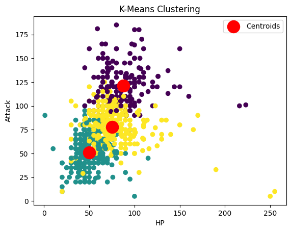

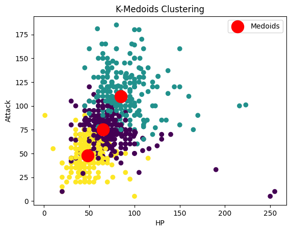

```
K-Means Prediction for Unknown Data: [1 1]
K-Medoids Prediction for Unknown Data: [2 2]
```

```python
import numpy as np
import pandas as pd
from sklearn.cluster import KMeans
from sklearn_extra.cluster import KMedoids
import matplotlib.pyplot as plt

# Load Pokémon dataset from CSV file
pokemon_data = pd.read_csv('pokemon.csv')

# Select three features for clustering
features = ['hp', 'attack', 'defense']
X = pokemon_data[features].values

# Perform K-Means clustering
kmeans = KMeans(n_clusters=3, random_state=42)
kmeans.fit(X)

# Perform K-Medoids clustering
kmedoids = KMedoids(n_clusters=3, random_state=42)
kmedoids.fit(X)

# Predict clusters for the data points
kmeans_labels = kmeans.labels_
kmedoids_labels = kmedoids.labels_

# Visualize the clusters for K-Means
plt.scatter(X[:, 0], X[:, 1], c=kmeans_labels, cmap='viridis')
plt.scatter(kmeans.cluster_centers_[:, 0], kmeans.cluster_centers_[:, 1], s=300, c='red', label='Centroids')
plt.xlabel('HP')
plt.ylabel('Attack')
plt.title('K-Means Clustering')
plt.legend()
plt.show()

# Visualize the clusters for K-Medoids
plt.scatter(X[:, 0], X[:, 1], c=kmedoids_labels, cmap='viridis')
plt.scatter(kmedoids.cluster_centers_[:, 0], kmedoids.cluster_centers_[:, 1], s=300, c='red', label='Medoids')
plt.xlabel('HP')
plt.ylabel('Attack')
plt.title('K-Medoids Clustering')
plt.legend()
plt.show()

# Predict clusters for unknown data points
unknown_data = np.array([[45,49, 49], [60, 50, 40]])  # Replace with your own data
kmeans_prediction = kmeans.predict(unknown_data)
kmedoids_prediction = kmedoids.predict(unknown_data)

print("K-Means Prediction for Unknown Data:", kmeans_prediction)
print("K-Medoids Prediction for Unknown Data:", kmedoids_prediction)
```

10. Implement hierarchical clustering algorithms and do prediction for unknown data.

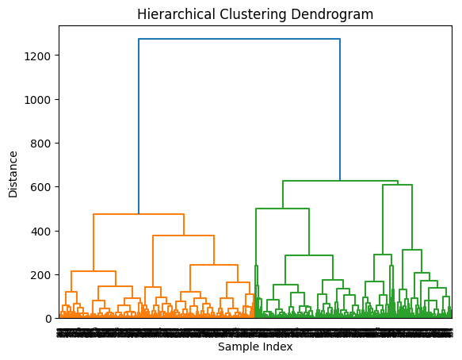

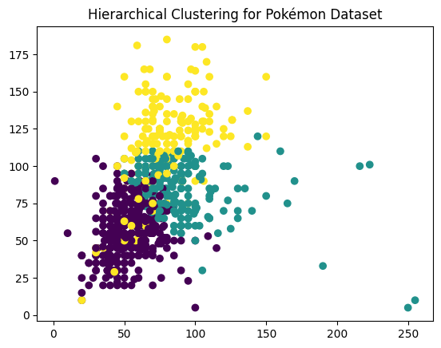

```
Clusters for Unknown Data: [1 1]
```

```python
import numpy as np
import pandas as pd
from scipy.cluster.hierarchy import dendrogram, linkage, fcluster
import matplotlib.pyplot as plt

# Load Pokémon dataset from CSV file
pokemon_data = pd.read_csv('pokemon.csv')

# Select features for clustering
features = ['hp', 'attack', 'defense']
X = pokemon_data[features].values

# Perform hierarchical clustering
linkage_matrix = linkage(X, method='ward', metric='euclidean')

# Create a dendrogram
dendrogram(linkage_matrix)
plt.title('Hierarchical Clustering Dendrogram')
plt.xlabel('Sample Index')
plt.ylabel('Distance')
plt.show()

# Determine the number of clusters using the dendrogram
num_clusters = 3  # Adjust this based on the dendrogram

# Perform clustering to assign data points to clusters
clusters = fcluster(linkage_matrix, t=num_clusters, criterion='maxclust')

# Visualize the clusters for the Pokémon dataset
plt.scatter(X[:, 0], X[:, 1], c=clusters, cmap='viridis')
plt.title('Hierarchical Clustering for Pokémon Dataset')

plt.show()

# Predict clusters for unknown data points
unknown_data = np.array([[80, 100, 70], [60, 50, 40]])  # Replace with your own data

# Rebuild the linkage matrix with the unknown data points
linkage_matrix_unknown = linkage(unknown_data, method='ward', metric='euclidean')

# Assign clusters to the unknown data points
unknown_clusters = fcluster(linkage_matrix_unknown, t=num_clusters, criterion='maxclust')

print("Clusters for Unknown Data:", unknown_clusters)
```

11. Implement DBSCAN clustering algorithms and do prediction for unknown data.

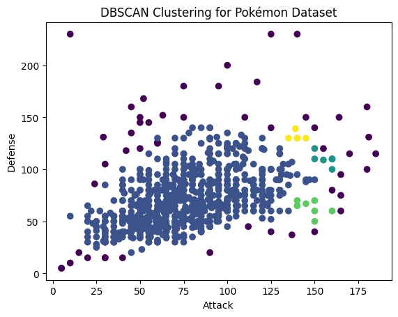

```
Clusters for Unknown Data: [-1 -1]
```

```python
import pandas as pd
from sklearn.cluster import DBSCAN
import matplotlib.pyplot as plt

# Load Pokémon dataset from CSV file
pokemon_data = pd.read_csv('pokemon.csv')

# Select features for DBSCAN clustering
features = ['attack', 'defense']
X = pokemon_data[features].values

# Perform DBSCAN clustering
dbscan = DBSCAN(eps=10, min_samples=5)  # Adjust eps and min_samples based on your dataset
clusters = dbscan.fit_predict(X)

# Visualize the clusters for the Pokémon dataset
plt.scatter(X[:, 0], X[:, 1], c=clusters, cmap='viridis')
plt.xlabel('Attack')
plt.ylabel('Defense')
plt.title('DBSCAN Clustering for Pokémon Dataset')
plt.show()

# Predict clusters for unknown data points
unknown_data = np.array([[100, 80], [50, 60]])
unknown_clusters = dbscan.fit_predict(unknown_data)

print("Clusters for Unknown Data:", unknown_clusters)
```

12. Implement apriori algorithm to get association rules.

```python
import pandas as pd
from mlxtend.frequent_patterns import apriori
from mlxtend.frequent_patterns import association_rules

# Load Pokémon dataset from CSV file
pokemon_data = pd.read_csv('pokemon.csv')

# Select relevant columns (features) for association rule mining
features = ['type1', 'type2', 'generation', 'is_legendary']
pokemon_data = pokemon_data[features]

# Convert categorical columns to strings to create itemsets
pokemon_data['type1'] = pokemon_data['type1'].astype(str)
pokemon_data['type2'] = pokemon_data['type2'].astype(str)
pokemon_data['generation'] = pokemon_data['generation'].astype(str)
pokemon_data['is_legendary'] = pokemon_data['is_legendary'].astype(str)

# Convert the dataset into a one-hot encoded DataFrame
one_hot_encoded_data = pd.get_dummies(pokemon_data)

# Apply Apriori algorithm to find frequent itemsets
frequent_itemsets = apriori(one_hot_encoded_data, min_support=0.1, use_colnames=True)

# Generate association rules
association_rules_df = association_rules(frequent_itemsets, metric="confidence", min_threshold=0.7)

# Print association rules
print("Association Rules:")
association_rules_df
```

```
Association Rules:
```

|  | antecedents | consequents | antecedent support | consequent support | support | confidence | lift | leverage | conviction | zhangs_metric |
| --- | --- | --- | --- | --- | --- | --- | --- | --- | --- | --- |
| 0 | (type1_normal) | (is_legendary_0) | 0.131086 | 0.912609 | 0.127341 | 0.971429 | 1.064452 | 0.007710 | 3.058677 | 0.069684 |
| 1 | (type1_water) | (is_legendary_0) | 0.142322 | 0.912609 | 0.134831 | 0.947368 | 1.038088 | 0.004947 | 1.660424 | 0.042779 |
| 2 | (type2_flying) | (is_legendary_0) | 0.118602 | 0.912609 | 0.106117 | 0.894737 | 0.980416 | -0.002120 | 0.830212 | -0.022161 |
| 3 | (type2_nan) | (is_legendary_0) | 0.479401 | 0.912609 | 0.448190 | 0.934896 | 1.024421 | 0.010684 | 1.342322 | 0.045791 |
| 4 | (generation_1) | (is_legendary_0) | 0.188514 | 0.912609 | 0.182272 | 0.966887 | 1.059476 | 0.010232 | 2.639201 | 0.069178 |
| 5 | (generation_2) | (is_legendary_0) | 0.124844 | 0.912609 | 0.117353 | 0.940000 | 1.030014 | 0.003420 | 1.456513 | 0.033296 |
| 6 | (generation_3) | (is_legendary_0) | 0.168539 | 0.912609 | 0.156055 | 0.925926 | 1.014592 | 0.002244 | 1.179775 | 0.017297 |
| 7 | (generation_4) | (is_legendary_0) | 0.133583 | 0.912609 | 0.117353 | 0.878505 | 0.962630 | -0.004556 | 0.719293 | -0.042885 |
| 8 | (generation_5) | (is_legendary_0) | 0.194757 | 0.912609 | 0.178527 | 0.916667 | 1.004446 | 0.000790 | 1.048689 | 0.005497 |

13. Implement backpropagation neural network algorithm.

```python
import pandas as pd
import numpy as np
from sklearn.model_selection import train_test_split
from sklearn.preprocessing import StandardScaler
from tensorflow.keras.models import Sequential
from tensorflow.keras.layers import Dense
from sklearn.metrics import mean_squared_error
# Load Pokémon dataset from CSV file
pokemon_data = pd.read_csv('pokemon.csv')

# Select features for the neural network
features = ['attack', 'defense', 'speed', 'hp']
X = pokemon_data[features].values

# Normalize the features
scaler = StandardScaler()
X = scaler.fit_transform(X)

# Target variable (label) - Using 'Total' as an example
y = pokemon_data['base_total'].values

# Split the data into training and testing sets
X_train, X_test, y_train, y_test = train_test_split(X, y, test_size=0.2, random_state=42)

# Build the neural network model
model = Sequential()
model.add(Dense(64, input_dim=len(features), activation='relu'))
model.add(Dense(32, activation='relu'))
model.add(Dense(1))  # Output layer, no activation for regression task

# Compile the model
model.compile(loss='mean_squared_error', optimizer='adam')

# Train the model
model.fit(X_train, y_train, epochs=100, batch_size=10, verbose=1)
mse = mean_squared_error(y_test, predictions)
print(f'Mean Squared Error: {mse:.2f}')
# Evaluate the model
loss = model.evaluate(X_test, y_test, verbose=0)
print(f'Test Loss: {loss:.2f}')

# Make predictions
predictions = model.predict(X_test)

# Print some sample predictions
print("Sample Predictions:")
for i in range(5):
    print(f"Actual: {y_test[i]}, Predicted: {predictions[i][0]:.2f}")
```

[output not shown]

14. Make a comparison tables for classification and clustering algorithms, for what you implemented here:

(a) Write unknown data: unknown_data = [[100, 80, 90, 70],[85, 35, 190, 170]] , [[50, 80, 90]]  
(b)Compare performance of classification algorithms

```python
import pandas as pd
from sklearn.model_selection import train_test_split
from sklearn.neighbors import KNeighborsClassifier
from sklearn.tree import DecisionTreeClassifier
from sklearn.svm import SVC
from sklearn.metrics import accuracy_score, precision_score, recall_score, f1_score

# Load Pokémon dataset from CSV file
pokemon_data = pd.read_csv('pokemon.csv')

# Select features for classification
features = ['attack', 'defense', 'speed', 'hp']
X = pokemon_data[features].values
y = pokemon_data['is_legendary'].values  # Target variable is 'Legendary'

# Split the data into training and testing sets
X_train, X_test, y_train, y_test = train_test_split(X, y, test_size=0.3, random_state=42)

# Train the models
knn_model = KNeighborsClassifier()
knn_model.fit(X_train, y_train)
y_pred_knn = knn_model.predict(X_test)

dt_model = DecisionTreeClassifier()
dt_model.fit(X_train, y_train)
y_pred_dt = dt_model.predict(X_test)

svm_model = SVC()
svm_model.fit(X_train, y_train)
y_pred_svm = svm_model.predict(X_test)

# Calculate evaluation metrics
accuracy_knn = accuracy_score(y_test, y_pred_knn)
precision_knn = precision_score(y_test, y_pred_knn, average='binary')
recall_knn = recall_score(y_test, y_pred_knn, average='binary')
f1_knn = f1_score(y_test, y_pred_knn, average='binary')

accuracy_dt = accuracy_score(y_test, y_pred_dt)
precision_dt = precision_score(y_test, y_pred_dt, average='binary')
recall_dt = recall_score(y_test, y_pred_dt, average='binary')
f1_dt = f1_score(y_test, y_pred_dt, average='binary')

accuracy_svm = accuracy_score(y_test, y_pred_svm)
precision_svm = precision_score(y_test, y_pred_svm, average='binary')
recall_svm = recall_score(y_test, y_pred_svm, average='binary')
f1_svm = f1_score(y_test, y_pred_svm, average='binary')

# Printing results in a table
print("Comparison Table for Classification Algorithms:")
print("{:<15} {:<10} {:<12} {:<10} {:<10}".format('Algorithm name', 'Accuracy', 'Precision', 'Recall', 'F-measure'))
print("{:<15} {:<10.2f} {:<12.2f} {:<10.2f} {:<10.2f}".format('KNN', accuracy_knn, precision_knn, recall_knn, f1_knn))
print("{:<15} {:<10.2f} {:<12.2f} {:<10.2f} {:<10.2f}".format('Decision Tree', accuracy_dt, precision_dt, recall_dt, f1_dt))
print("{:<15} {:<10.2f} {:<12.2f} {:<10.2f} {:<10.2f}".format('SVM', accuracy_svm, precision_svm, recall_svm, f1_svm))

# Make predictions for unknown data (replace with your own data)
unknown_data = [[100, 80, 90, 70],[85, 35, 190, 170]]
prediction_knn = knn_model.predict(unknown_data)
prediction_dt = dt_model.predict(unknown_data)
prediction_svm = svm_model.predict(unknown_data)

print("KNN Prediction for Unknown Data:", prediction_knn)
print("Decision Tree Prediction for Unknown Data:", prediction_dt)
print("SVM Prediction for Unknown Data:", prediction_svm)
```

```
Comparison Table for Classification Algorithms:
Algorithm name  Accuracy   Precision    Recall     F-measure
KNN             0.92       0.80         0.32       0.46
Decision Tree   0.91       0.61         0.44       0.51
SVM             0.92       0.86         0.24       0.38
KNN Prediction for Unknown Data: [0 1]
Decision Tree Prediction for Unknown Data: [0 1]
SVM Prediction for Unknown Data: [0 0]
```

(c) Compare performance of clustering algorithms you implemented.

```python
import pandas as pd
from sklearn.cluster import AgglomerativeClustering, DBSCAN, KMeans
from sklearn_extra.cluster import KMedoids
from sklearn.preprocessing import StandardScaler
from sklearn.metrics import silhouette_score

# Load Pokémon dataset from CSV file
pokemon_data = pd.read_csv('pokemon.csv')

# Select features for clustering
features = ['attack', 'defense', 'speed']
X = pokemon_data[features].values

# Standardize the features
scaler = StandardScaler()
X = scaler.fit_transform(X)

# Hierarchical Clustering
agg = AgglomerativeClustering(n_clusters=3)
agg_labels = agg.fit_predict(X)
agg_silhouette_score = silhouette_score(X, agg_labels)

# DBSCAN
dbscan = DBSCAN(eps=0.5, min_samples=5)
dbscan_labels = dbscan.fit_predict(X)
dbscan_silhouette_score = silhouette_score(X, dbscan_labels)

# K-Medoids
kmedoids = KMedoids(n_clusters=3)
kmedoids_labels = kmedoids.fit_predict(X)
kmedoids_silhouette_score = silhouette_score(X, kmedoids_labels)

# K-Means
kmeans = KMeans(n_clusters=3, random_state=0)
kmeans_labels = kmeans.fit_predict(X)
kmeans_silhouette_score = silhouette_score(X, kmeans_labels)

# Printing the silhouette scores
print("Silhouette Scores:")
print(f"Hierarchical Clustering: {agg_silhouette_score:.2f}")
print(f"DBSCAN: {dbscan_silhouette_score:.2f}")
print(f"K-Medoids: {kmedoids_silhouette_score:.2f}")
print(f"K-Means: {kmeans_silhouette_score:.2f}")


unknown_data = [[50, 80, 90]]
scaled_unknown_data = scaler.transform(unknown_data)

dbscan_prediction = dbscan.fit_predict(scaled_unknown_data)

kmeans_prediction = kmeans.predict(scaled_unknown_data)

print("DBSCAN Prediction for Unknown Data:", dbscan_prediction)

print("K-Means Prediction for Unknown Data:", kmeans_prediction)
```

```
Silhouette Scores:
Hierarchical Clustering: 0.23
DBSCAN: 0.27
K-Medoids: 0.25
K-Means: 0.33
DBSCAN Prediction for Unknown Data: [-1]
K-Means Prediction for Unknown Data: [1]
```

(d) Use different distance measures as in CO2’s 3rd assignment and make a table to compare the performance of clustering algorithms you implemented.

```python
import numpy as np
import pandas as pd
from sklearn.cluster import KMeans
from sklearn_extra.cluster import KMedoids
from sklearn.cluster import DBSCAN
from scipy.spatial.distance import cdist, cityblock, cosine, hamming

# Load Pokémon dataset from CSV file
pokemon_data = pd.read_csv('pokemon.csv')

# Select features for clustering
features = ['attack', 'defense', 'speed', 'hp']
X = pokemon_data[features].values

# Standardize the features
X = (X - X.mean(axis=0)) / X.std(axis=0)

# Initialize clustering algorithms
kmeans = KMeans(n_clusters=3, random_state=0)
kmedoids = KMedoids(n_clusters=3, random_state=0, metric='manhattan')  # You can change the metric if needed
dbscan = DBSCAN(eps=0.5, min_samples=5, metric='euclidean')  # You can change the metric if needed

# Fit the clustering algorithms and get cluster assignments
kmeans_labels = kmeans.fit_predict(X)
kmedoids_labels = kmedoids.fit_predict(X)
dbscan_labels = dbscan.fit_predict(X)

# Calculate distances for KMeans
kmeans_distances = {
    'Euclidean': cdist(X, kmeans.cluster_centers_, 'euclidean'),
    'Minkowski': cdist(X, kmeans.cluster_centers_, 'minkowski', p=3),
    'Manhattan': cdist(X, kmeans.cluster_centers_, 'cityblock'),
    'Cosine': cdist(X, kmeans.cluster_centers_, 'cosine'),
    'Simple matching coefficient': cdist(X, kmeans.cluster_centers_, 'hamming')
}

# Calculate distances for KMedoids
kmedoids_distances = {
    'Euclidean': cdist(X, X[kmedoids.medoid_indices_], 'euclidean'),
    'Minkowski': cdist(X, X[kmedoids.medoid_indices_], 'minkowski', p=3),
    'Manhattan': cdist(X, X[kmedoids.medoid_indices_], 'cityblock'),
    'Cosine': cdist(X, X[kmedoids.medoid_indices_], 'cosine'),
    'Simple matching coefficient': cdist(X, X[kmedoids.medoid_indices_], 'hamming')
}

# Calculate distances for DBSCAN
dbscan_distances = {
    'Euclidean': cdist(X, X[dbscan.labels_ != -1], 'euclidean'),
    'Minkowski': cdist(X, X[dbscan.labels_ != -1], 'minkowski', p=3),
    'Manhattan': cdist(X, X[dbscan.labels_ != -1], 'cityblock'),
    'Cosine': cdist(X, X[dbscan.labels_ != -1], 'cosine'),
    'Simple matching coefficient': cdist(X, X[dbscan.labels_ != -1], 'hamming')
}

# Create a table to compare the performance of clustering algorithms using different distance measures
print("Comparison Table for Clustering Algorithms with Different Distance Measures:")
print("{:<30} {:<15} {:<15} {:<15}".format('Distance Measure', 'KMeans', 'KMedoids', 'DBSCAN'))
for key in kmeans_distances:
    print("{:<30} {:<15.2f} {:<15.2f} {:<15.2f}".format(key, np.mean(kmeans_distances[key]),
                                                       np.mean(kmedoids_distances[key]),
                                                       np.mean(dbscan_distances[key])))
```

```
Comparison Table for Clustering Algorithms with Different Distance Measures:
Distance Measure               KMeans          KMedoids        DBSCAN
Euclidean                      2.18            2.08            2.27
Minkowski                      1.88            1.81            1.98
Manhattan                      3.79            3.60            3.90
Cosine                         1.01            1.00            0.98
Simple matching coefficient    1.00            0.96            0.97
```

15. Write any deep learning program of your choice.

```python
import numpy as np
import pandas as pd
from tensorflow.keras.models import Sequential
from tensorflow.keras.layers import Dense
from tensorflow.keras.utils import to_categorical
from sklearn.model_selection import train_test_split

# Load Pokémon dataset from CSV file
pokemon_data = pd.read_csv('pokemon.csv')

# Select features for the neural network
features = ['attack', 'defense', 'speed', 'hp']
X = pokemon_data[features].values
y = pokemon_data['is_legendary'].values

# Standardize the features
X = (X - X.mean(axis=0)) / X.std(axis=0)

# Convert target labels to categorical
y = to_categorical(y)

# Split the data into training and testing sets
X_train, X_test, y_train, y_test = train_test_split(X, y, test_size=0.2, random_state=42)

# Build the neural network
model = Sequential()
model.add(Dense(10, input_dim=4, activation='relu'))
model.add(Dense(8, activation='relu'))
model.add(Dense(2, activation='softmax'))  # 2 classes for 'is_legendary'

# Compile the model
model.compile(loss='categorical_crossentropy', optimizer='adam', metrics=['accuracy'])

# Train the model
model.fit(X_train, y_train, epochs=150, batch_size=10, verbose=1)

# Evaluate the model
loss, accuracy = model.evaluate(X_test, y_test, verbose=0)
print(f'Test loss: {loss:.4f}')
print(f'Test accuracy: {accuracy:.4f}')
```

```
Test loss: 0.2747
Test accuracy: 0.9130
```